# Introduction to diffanal2

## What is diffanal2?

Based on the original `diffanal.R` script, `diffanal2` supports performing differential gene expression analysis of microarray data using asymptotic and permutation t-tests, as well as a new feature to support using `limma` - *Linear Models for Microarray Data*. It also supports accepting an arbitrary scoring function, so you can extend it without needing to rewrite the guts of the program.

## A Brief Example

Start by loading a microarray dataset. We'll use a lymphoma sample study with 116 participants.

```r
data(lymphoma.2010)
lymphoma
```

```
## ExpressionSet (storageMode: lockedEnvironment)
## assayData: 19081 features, 116 samples
##   element names: exprs
## protocolData: none
## phenoData
##   sampleNames: MS_D_1001 MS_D_1002 ... old_c514 (116 total)
##   varLabels: SampleID Class ... COO (7 total)
##   varMetadata: labelDescription
## featureData: none
## experimentData: use 'experimentData(object)'
## Annotation: HG_U133plus2
```

Each sample in the study was clinically characterized several times.

```r
head(pData(lymphoma))
```

```
##            SampleID Class meta.1 best.10_13     cc gold.standard  COO
## MS_D_1001 MS_D_1001    HR     HR         HR     HR            HR <NA>
## MS_D_1002 MS_D_1002   BCR    BCR        BCR OxPhos          <NA>  GCB
## MS_D_1003 MS_D_1003   BCR    BCR        BCR    BCR           BCR  GCB
## MS_D_1004 MS_D_1004    HR OxPhos       <NA>     HR          <NA> <NA>
## MS_D_1005 MS_D_1005    HR     HR         HR     HR            HR  ABC
## MS_D_1006 MS_D_1006    HR     HR         HR    BCR          <NA> <NA>
```

For now, let's assume the column **`meta.1`** as being the phenotype of interest for this dataset. While `diffanal2` can operate on a matrix of expression data and a phenotype vector or data.frame, it knows how to unpack an `ExpressionSet` object and will assume me mean for the phenotype to be taken from the `pData` member of the object unless told otherwise. We can specify the predictor phenotype either as the first parameter of a `formula` object passed to the `model.formula` parameter, or as a single string character vector to the `predictor` parameter.

To start small, we can use a regular t-test for our scoring function. We'll also turn on the verbose option to see each step in the pipeline. This command will verify that the data is clean, without any NA values in the phenotype, removing any samples that do, perform variance filtering using the `mad` statistic to discard genes with extreme variability, keeping the top 5000 (see the `ngenes.filter` parameter to change this), and then partition and test the data.

```r
library('diffanal2')
options(verbose=T)
t.test_meta.1 <- df2.t.test(lymphoma, model.formula = ~ meta.1)
```

```
## Cleaning data, removing samples with NA phenotype data
## 0  samples dropped
## Variation filtering based on mad ..
## done.
##
## Selecting top 5000 by mad ..
## done, 5000 genes selected.
##
## Calculating summary statistics
```

For a multinomial phenotype like this one, the test will run in one-vs-all mode by default, comparing all of the memebers of one class to all members of all other classes, for each class present in the phenotype selected. The results are returned as an instance of `diffanal.results data.frame`, an S3 class built on top of a data.frame with additional methods.

```r
head(t.test_meta.1)
```

```
##                            gene BCR..Not.BCR..p.value HR..Not.HR..p.value
## ENSG00000121774 ENSG00000121774             4.814e-18           0.1020927
## ENSG00000099783 ENSG00000099783             3.452e-17           0.1338365
## ENSG00000162298 ENSG00000162298             3.411e-17           0.1193124
## ENSG00000129351 ENSG00000129351             1.140e-16           0.0027089
## ENSG00000099246 ENSG00000099246             2.190e-16           0.0007024
## ENSG00000132182 ENSG00000132182             2.783e-16           0.2912822
##                 OxPhos..Not.OxPhos..p.value BCR..Not.BCR..adj.p.value
## ENSG00000121774                   4.897e-07                 2.407e-14
## ENSG00000099783                   4.176e-10                 5.754e-14
## ENSG00000162298                   7.395e-09                 5.754e-14
## ENSG00000129351                   1.380e-07                 1.424e-13
## ENSG00000099246                   3.201e-07                 2.190e-13
## ENSG00000132182                   8.146e-14                 2.319e-13
##                 HR..Not.HR..adj.p.value OxPhos..Not.OxPhos..adj.p.value
## ENSG00000121774                0.143298                       2.898e-06
## ENSG00000099783                0.181843                       6.779e-09
## ENSG00000162298                0.164433                       7.665e-08
## ENSG00000129351                0.005749                       9.480e-07
## ENSG00000099246                0.001751                       1.991e-06
## ENSG00000132182                0.358722                       5.737e-12
##                 BCR..Not.BCR..t.score HR..Not.HR..t.score
## ENSG00000121774                -10.40               1.655
## ENSG00000099783                -10.22               1.513
## ENSG00000162298                -10.12               1.572
## ENSG00000129351                -10.44               3.067
## ENSG00000099246                 10.41              -3.503
## ENSG00000132182                -10.21               1.061
##                 OxPhos..Not.OxPhos..t.score BCR..mean HR..mean
## ENSG00000121774                       5.477    1163.8    836.1
## ENSG00000099783                       6.984    1985.4   1478.2
## ENSG00000162298                       6.433     678.8    377.5
## ENSG00000129351                       5.743     451.0    294.4
## ENSG00000099246                      -5.461     292.3    381.5
## ENSG00000132182                       8.647     250.9    150.5
##                 OxPhos..mean Not.BCR..mean Not.HR..mean Not.OxPhos..mean
## ENSG00000121774        729.8         780.9        944.1           1004.3
## ENSG00000099783       1274.7        1372.5       1625.6           1738.5
## ENSG00000162298        281.7         327.7        477.7            532.1
## ENSG00000129351        271.1         282.3        359.9            374.8
```

[output cut: 36 more lines]

```
## ENSG00000132182                  0.8447                          0.5314
##                 BCR..mad HR..mad OxPhos..mad Not..BCR..mad Not..HR..mad
## ENSG00000121774   180.71  188.69      166.54        172.06       310.18
## ENSG00000099783   332.17  215.52      263.93        301.93       499.18
## ENSG00000162298   207.51  134.11      120.37        134.53       299.86
## ENSG00000129351   113.00   47.29       61.52         51.02       130.92
## ENSG00000099246    43.45   56.76       55.52         56.98        64.08
## ENSG00000132182    69.72   42.40       32.74         41.38        83.98
##                 Not..OxPhos..mad
## ENSG00000121774           230.72
## ENSG00000099783           313.44
## ENSG00000162298           276.36
## ENSG00000129351           112.60
## ENSG00000099246            68.06
## ENSG00000132182            76.17
```

The data.frame shown has a column for each class compared for each summary statistic (`mean`,`median`, `std.dev`, `mad`), and a mean `fold.change`, `t-score`, `p-value` and FDR-adjusted `p-value` for each class-class comparison done. The table is also sorted by FDR-adjusted `p-value`, smallest to largest. In this case, there were six classes (`BCR, HR, OxPhos, Not.BCR, Not.HR,` and `Not.OxPhos`) and three comparisons (`BCR-Not.BCR, HR-Not.HR` and `OxPhos-Not.OxPhos`). Each of these types of statistics is considered a “column.group”, and can be accessed using the `column.groups` function to get the list of column groups in the table and the corresponding columns, or given the name of a group, say, “means”, all columns from that group using the `group` function.

```r
column.groups(t.test_meta.1)
```

```
## $p.values
## [1] "BCR..Not.BCR..p.value"       "HR..Not.HR..p.value"
## [3] "OxPhos..Not.OxPhos..p.value"
##
## $adj.p.values
## [1] "BCR..Not.BCR..adj.p.value"       "HR..Not.HR..adj.p.value"
## [3] "OxPhos..Not.OxPhos..adj.p.value"
##
## $t.scores
## [1] "BCR..Not.BCR..t.score"       "HR..Not.HR..t.score"
## [3] "OxPhos..Not.OxPhos..t.score"
##
## $means
## [1] "BCR..mean"        "HR..mean"         "OxPhos..mean"
## [4] "Not.BCR..mean"    "Not.HR..mean"     "Not.OxPhos..mean"
##
## $std.devs
## [1] "BCR..std.dev"        "HR..std.dev"         "OxPhos..std.dev"
## [4] "Not.BCR..std.dev"    "Not.HR..std.dev"     "Not.OxPhos..std.dev"
##
## $medians
## [1] "BCR..median"         "HR..median"          "OxPhos..median"
## [4] "Not..BCR..median"    "Not..HR..median"     "Not..OxPhos..median"
##
## $fold.changes
## [1] "BCR..Not.BCR..fold.change"       "HR..Not.HR..fold.change"
## [3] "OxPhos..Not.OxPhos..fold.change"
##
## $mads
## [1] "BCR..mad"         "HR..mad"          "OxPhos..mad"
## [4] "Not..BCR..mad"    "Not..HR..mad"     "Not..OxPhos..mad"
##
## $descriptives
## [1] "gene"
```

```r
head(group(t.test_meta.1, "means"))
```

```
##                 BCR..mean HR..mean OxPhos..mean Not.BCR..mean Not.HR..mean
## ENSG00000121774    1163.8    836.1        729.8         780.9        944.1
## ENSG00000099783    1985.4   1478.2       1274.7        1372.5       1625.6
## ENSG00000162298     678.8    377.5        281.7         327.7        477.7
## ENSG00000129351     451.0    294.4        271.1         282.3        359.9
## ENSG00000099246     292.3    381.5        393.5         387.7        343.5
## ENSG00000132182     250.9    150.5        107.4         128.1        178.2
##                 Not.OxPhos..mean
## ENSG00000121774           1004.3
## ENSG00000099783           1738.5
## ENSG00000162298            532.1
## ENSG00000129351            374.8
## ENSG00000099246            335.7
## ENSG00000132182            202.1
```

There are a lot of columns in this table, and usually, only one of the comparisons is interesting, the one that minimizes or maximizes the statistic. To assign each gene to a class, we can use the `unique.diffanal.results` (as an S3 method, we only need to write `unique`), specifying a column group and a scoring function to choose the best class for each gene from the set of scores in each group. The default column group is `adj.p.values` and the default scoring function is `base::which.min`.

```r
ut.test_meta.1 <- unique(t.test_meta.1, criteria.column = "adj.p.values", score.fn = which.min)
head(ut.test_meta.1)
```

```
##                            gene        class class..p.value
## ENSG00000121774 ENSG00000121774 BCR..Not.BCR      4.814e-18
## ENSG00000099783 ENSG00000099783 BCR..Not.BCR      3.452e-17
## ENSG00000162298 ENSG00000162298 BCR..Not.BCR      3.411e-17
## ENSG00000129351 ENSG00000129351 BCR..Not.BCR      1.140e-16
## ENSG00000099246 ENSG00000099246 BCR..Not.BCR      2.190e-16
## ENSG00000132182 ENSG00000132182 BCR..Not.BCR      2.783e-16
##                 class..adj.p.value class..t.score class..mean
## ENSG00000121774          2.407e-14         -10.40      1163.8
## ENSG00000099783          5.754e-14         -10.22      1985.4
## ENSG00000162298          5.754e-14         -10.12       678.8
## ENSG00000129351          1.424e-13         -10.44       451.0
## ENSG00000099246          2.190e-13          10.41       292.3
## ENSG00000132182          2.319e-13         -10.21       250.9
##                 class..std.dev class..median class..fold.change class..mad
## ENSG00000121774         151.07        1149.6             1.4904     180.71
## ENSG00000099783         336.49        1890.6             1.4466     332.17
## ENSG00000162298         211.46         664.8             2.0711     207.51
## ENSG00000129351          98.66         452.6             1.5976     113.00
## ENSG00000099246          39.83         288.4             0.7539      43.45
## ENSG00000132182          83.05         227.5             1.9585      69.72
```

All of the statistic columns have been reduced to just `class..<statistic>`, and a new `class` column was added, showing which class that gene was assigned to. Note that since the gene order hasn't changed, many of the genes will appear to be sorted by class, but this is a side effect of the initial ordering, not of the `unique` function.

## Using `limma` with diffanal2

```r
limma_meta.1 <- df2.limma(lymphoma, model.formula= ~meta.1)
```

```
## Cleaning data, removing samples with NA phenotype data
## 0  samples dropped
## Variation filtering based on mad ..
## done.
##
## Selecting top 5000 by mad ..
## done, 5000 genes selected.
##
## Calculating summary statistics
```

```r
head(limma_meta.1)
```

```
##                            gene BCR..Not.BCR..p.value HR..Not.HR..p.value
## ENSG00000054118 ENSG00000054118             8.617e-09           0.0733121
## ENSG00000213020 ENSG00000213020             3.674e-08           0.0002891
## ENSG00000196584 ENSG00000196584             6.939e-07           0.0005985
## ENSG00000153310 ENSG00000153310             2.706e-06           0.0029840
## ENSG00000186517 ENSG00000186517             1.333e-05           0.2915297
## ENSG00000168802 ENSG00000168802             2.573e-05           0.1312186
##                 OxPhos..Not.OxPhos..p.value BCR..Not.BCR..adj.p.value
## ENSG00000054118                   0.0000241                 4.308e-05
## ENSG00000213020                   0.0359422                 9.184e-05
## ENSG00000196584                   0.0950319                 1.157e-03
## ENSG00000153310                   0.0638451                 3.383e-03
## ENSG00000186517                   0.0006691                 1.333e-02
## ENSG00000168802                   0.0050177                 1.689e-02
##                 HR..Not.HR..adj.p.value OxPhos..Not.OxPhos..adj.p.value
## ENSG00000054118                  0.6192                         0.02629
## ENSG00000213020                  0.1205                         0.33466
## ENSG00000196584                  0.1468                         0.44869
## ENSG00000153310                  0.2720                         0.39362
## ENSG00000186517                  0.7951                         0.09637
## ENSG00000168802                  0.6768                         0.19133
##                 BCR..Not.BCR..lods HR..Not.HR..lods
## ENSG00000054118              9.462          -4.2630
## ENSG00000213020              8.171           0.1916
## ENSG00000196584              5.558          -0.4153
## ENSG00000153310              4.350          -1.7416
## ENSG00000186517              2.939          -5.2079
## ENSG00000168802              2.359          -4.6819
##                 OxPhos..Not.OxPhos..lods BCR..Not.BCR..t.score
## ENSG00000054118                   2.3814                 6.203
## ENSG00000213020                  -3.7938                -5.896
## ENSG00000196584                  -4.5395                -5.248
## ENSG00000153310                  -4.2399                -4.933
## ENSG00000186517                  -0.4883                 4.547
## ENSG00000168802                  -2.1910                 4.382
##                 HR..Not.HR..t.score OxPhos..Not.OxPhos..t.score BCR..mean
## ENSG00000054118              -1.807                      -4.399     372.4
## ENSG00000213020               3.737                       2.122     114.9
## ENSG00000196584               3.528                       1.683     106.8
## ENSG00000153310               3.033                       1.871     101.8
```

[output cut: 50 more lines]

```
## ENSG00000168802                          0.9046    67.09   59.64
##                 OxPhos..mad Not..BCR..mad Not..HR..mad Not..OxPhos..mad
## ENSG00000054118       69.44         62.93        67.06            70.27
## ENSG00000213020       49.09         52.28        52.30            54.86
## ENSG00000196584       27.83         41.50        41.14            47.42
## ENSG00000153310       72.86         84.16        93.66            78.99
## ENSG00000186517       34.93         75.41        70.55            77.32
## ENSG00000168802       72.89         72.84        77.65            65.99
##                 F.score F.p.value
## ENSG00000054118  20.518 2.294e-08
## ENSG00000213020  17.727 1.881e-07
## ENSG00000196584  14.246 2.899e-06
## ENSG00000153310  12.337 1.373e-05
## ENSG00000186517  11.438 2.901e-05
## ENSG00000168802   9.962 1.011e-04
```

The result table for a limma strategy is similar to the t-test strategy, with a few key differences. There is an additional comparison statistic, `lods`, standing for log-odds of differential expression, which `limma::eBayes` computes. The class means and standard errors are also extracted from `limma::lmFit`, and the complementary class means are backsolved from `limma::contrast.fit`'s fold change coefficient. Additionally, the table has two additional un-classed statistics, `F.score` and `F.p.value`, which are not part of the other strategies by default (see `do.F.stat` parameter in `do.diffanal2` for how to add it).

The limma strategy can also calculate the influence of a confounding variable has on the mean expression of a gene, and use that information to calculate the “true” mean gene expression as a result of the predictor variable. A confounder can be specified by adding additional terms to the `model.formula` parameter, or by specifying a list of character strings to the `confounder` parameter. While there is no reason to believe so, what if we believed that the Class label in the phenotype data was a confounder? To test this, we would run:

```r
limma_meta.1xClass <- df2.limma(lymphoma, model.formula= ~ meta.1 + Class)
```

```
## Cleaning data, removing samples with NA phenotype data
## 0  samples dropped
## Variation filtering based on mad ..
## done.
##
## Selecting top 5000 by mad ..
## done, 5000 genes selected.
##
## Calculating summary statistics
```

```r
head(limma_meta.1xClass)
```

```
##                            gene BCR..Not.BCR..p.value HR..Not.HR..p.value
## ENSG00000180957 ENSG00000180957             3.353e-07           0.0061995
## ENSG00000184787 ENSG00000184787             1.953e-06           0.0008755
## ENSG00000213020 ENSG00000213020             2.215e-06           0.0019137
## ENSG00000173875 ENSG00000173875             3.936e-06           0.0002097
## ENSG00000120690 ENSG00000120690             1.142e-05           0.0770862
## ENSG00000088448 ENSG00000088448             1.782e-05           0.3224916
##                 OxPhos..Not.OxPhos..p.value BCR..Not.BCR..adj.p.value
## ENSG00000180957                   0.0044158                  0.001676
## ENSG00000184787                   0.0564685                  0.003692
## ENSG00000213020                   0.0365055                  0.003692
## ENSG00000173875                   0.1685358                  0.004919
## ENSG00000120690                   0.0034584                  0.008911
## ENSG00000088448                   0.0004827                  0.008911
##                 HR..Not.HR..adj.p.value OxPhos..Not.OxPhos..adj.p.value
## ENSG00000180957                 0.28330                          0.2066
## ENSG00000184787                 0.15614                          0.3567
## ENSG00000213020                 0.19528                          0.3131
## ENSG00000173875                 0.09367                          0.5046
## ENSG00000120690                 0.63705                          0.1973
## ENSG00000088448                 0.85360                          0.1508
##                 BCR..Not.BCR..lods HR..Not.HR..lods
## ENSG00000180957              6.279          -2.3407
## ENSG00000184787              4.693          -0.7247
## ENSG00000213020              4.580          -1.3752
## ENSG00000173875              4.064           0.4751
## ENSG00000120690              3.110          -4.3175
## ENSG00000088448              2.712          -5.2922
##                 OxPhos..Not.OxPhos..lods BCR..Not.BCR..t.score
## ENSG00000180957                  -2.0596                -5.418
## ENSG00000184787                  -4.0603                -5.014
## ENSG00000213020                  -3.7303                -4.984
## ENSG00000173875                  -4.8432                -4.848
## ENSG00000120690                  -1.8612                -4.589
## ENSG00000088448                  -0.2412                -4.478
##                 HR..Not.HR..t.score OxPhos..Not.OxPhos..t.score BCR..mean
## ENSG00000180957              2.7884                       2.904     462.8
## ENSG00000184787              3.4171                       1.927     275.9
## ENSG00000213020              3.1765                       2.116     118.1
## ENSG00000173875              3.8292                       1.386     217.6
```

[output cut: 50 more lines]

```
## ENSG00000088448                           1.425   141.81  174.30
##                 OxPhos..mad Not..BCR..mad Not..HR..mad Not..OxPhos..mad
## ENSG00000180957      118.82         96.16        92.94            77.57
## ENSG00000184787       83.76         82.82        80.21            56.01
## ENSG00000213020       49.09         52.28        52.30            54.86
## ENSG00000173875       94.66         82.27        90.77            78.14
## ENSG00000120690      183.71        159.45       181.75           163.11
## ENSG00000088448      156.16        177.42       155.91           153.97
##                 F.score F.p.value
## ENSG00000180957   14.74 2.001e-06
## ENSG00000184787   13.37 6.013e-06
## ENSG00000213020   12.93 8.591e-06
## ENSG00000173875   13.40 5.886e-06
## ENSG00000120690   10.59 5.987e-05
## ENSG00000088448   10.73 5.334e-05
```

To get an idea of how the addition of a confounder changes the mean calculation, try this plot:

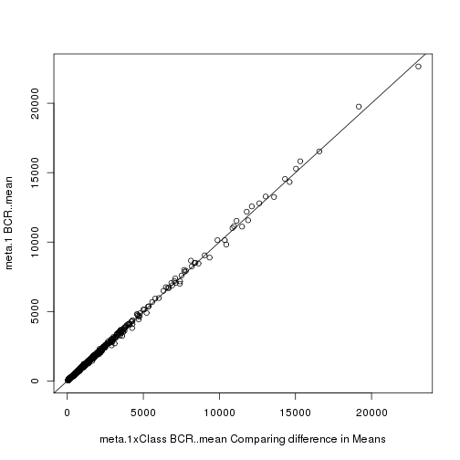

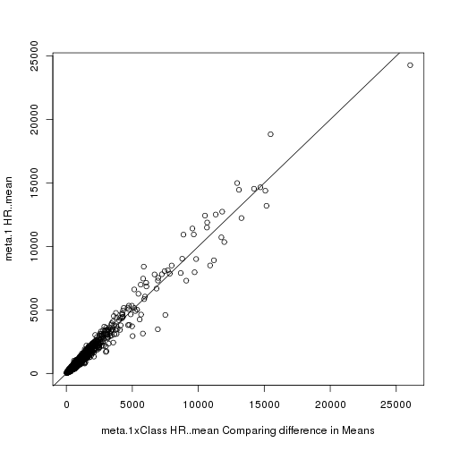

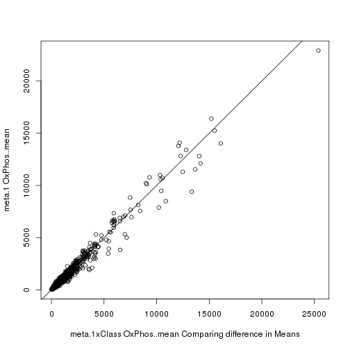

```r
gs <- intersect(row.names(limma_meta.1), row.names(t.test_meta.1))
means.meta.1 <- group(limma_meta.1[gs,], "means")
means.meta.1xClass <- group(limma_meta.1xClass[gs,], "means")
means.frame <- cbind(m1 = means.meta.1, m2 = means.meta.1xClass)
for(i in seq(1:3)){
  plot(means.meta.1[,i] ~ means.meta.1xClass[,i],
       ylab=paste("meta.1", colnames(means.meta.1)[i]),
       xlab=paste("meta.1xClass", colnames(means.meta.1xClass)[i],
                  main = "Comparing difference in Means"))
  abline(0,1)
}
```

## Running permutation t-tests

A a core part of `diffanal` was the permutation test, which let it you permute the class/phenotype labels to test the robustness of the class results by using the `perm.t.test` strategy. This test also allows you to specify confounders, and will only generate label permutations that swap samples within the same confounder class. At this time, only binary confounders are supported. The number of permutations ran is controlled by the `nperm` parameter, and augmented by the `exhaustive` parameter, which limits the number of permutations to generate to the maximum number of unique permutations available.

Because each class comparison is reperformed many, many times, this strategy can run each class comparison in parallel, controlling the number of parallel processors used by changing the `ncores` parameter. If `ncores` is 1, the default, the comparisons run sequentially. This multiprocessing is done using `plyr` and `doMC`. `doMC` makes initializing the environment of the child processes trivial because they are `fork`s of the parent process.

```r
perm.t.meta.1 <- df2.perm.t.test(lymphoma, model.formula= ~ meta.1 + Class,
                                 nperm = 100, ncores=3)
```

```
## Cleaning data, removing samples with NA phenotype data
## 0  samples dropped
## Variation filtering based on mad ..
## done.
##
## Selecting top 5000 by mad ..
## done, 5000 genes selected.
##
## Running tests in parallel
## Calculating summary statistics
## done
```

```r
head(perm.t.meta.1)
```

```
##                                      gene BCR..Not.BCR..asymp.p.value
## ENSG00000138755           ENSG00000138755                   1.738e-03
## ENSG00000204287           ENSG00000204287                   1.634e-03
## AFFX-HSAC07/X00351_3 AFFX-HSAC07/X00351_3                   7.258e-08
## ENSG00000034510           ENSG00000034510                   2.238e-03
## AFFX-HSAC07/X00351_M AFFX-HSAC07/X00351_M                   2.739e-09
## ENSG00000123416           ENSG00000123416                   8.677e-05
##                      HR..Not.HR..asymp.p.value
## ENSG00000138755                      3.176e-09
## ENSG00000204287                      9.230e-01
## AFFX-HSAC07/X00351_3                 1.900e-02
## ENSG00000034510                      1.688e-12
## AFFX-HSAC07/X00351_M                 4.551e-01
## ENSG00000123416                      1.242e-02
##                      OxPhos..Not.OxPhos..asymp.p.value
## ENSG00000138755                              6.569e-02
## ENSG00000204287                              1.497e-04
## AFFX-HSAC07/X00351_3                         2.962e-09
## ENSG00000034510                              1.216e-02
## AFFX-HSAC07/X00351_M                         6.008e-07
## ENSG00000123416                              1.612e-01
##                      BCR..Not.BCR..adj.asymp.p.value
## ENSG00000138755                            5.972e-03
## ENSG00000204287                            5.674e-03
## AFFX-HSAC07/X00351_3                       1.226e-06
## ENSG00000034510                            7.397e-03
## AFFX-HSAC07/X00351_M                       7.737e-08
## ENSG00000123416                            4.842e-04
##                      HR..Not.HR..adj.asymp.p.value
## ENSG00000138755                          4.609e-08
## ENSG00000204287                          9.378e-01
## AFFX-HSAC07/X00351_3                     3.246e-02
## ENSG00000034510                          1.592e-10
## AFFX-HSAC07/X00351_M                     5.237e-01
## ENSG00000123416                          2.234e-02
##                      OxPhos..Not.OxPhos..adj.asymp.p.value
## ENSG00000138755                                  1.038e-01
## ENSG00000204287                                  4.546e-04
## AFFX-HSAC07/X00351_3                             3.517e-08
## ENSG00000034510                                  2.337e-02
```

[output cut: 120 more lines]

```
## ENSG00000123416                               0.9207     1504    2263
##                      OxPhos..mad Not..BCR..mad Not..HR..mad
## ENSG00000138755             1939          4293         1719
## ENSG00000204287             2257          2195         3214
## AFFX-HSAC07/X00351_3        1621          2076         2813
## ENSG00000034510             2448          2276         1828
## AFFX-HSAC07/X00351_M        1370          1764         2569
## ENSG00000123416             1566          1986         2003
##                      Not..OxPhos..mad
## ENSG00000138755                  4079
## ENSG00000204287                  2684
## AFFX-HSAC07/X00351_3             2128
## ENSG00000034510                  2031
## AFFX-HSAC07/X00351_M             1973
## ENSG00000123416                  2566
```

The permutation test strategy outputs the asymptotic t statistic, resulting p-value, and FDR p-value, as well as the permutation test's `max-t-score`, and the `permutation p-value` and the associated FDR. The results should be otherwise identical to the normal t-test strategy.

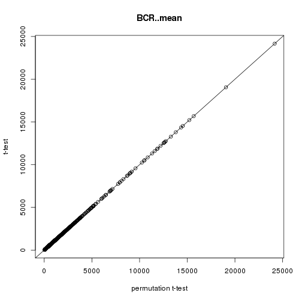

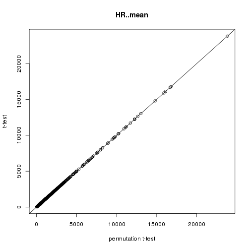

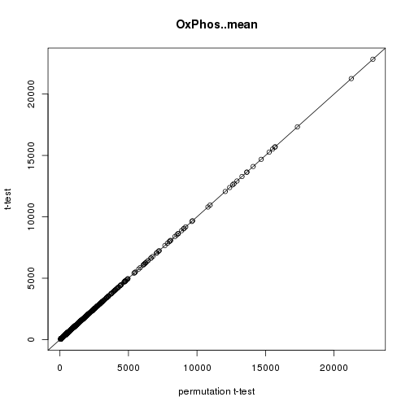

```r
gs2 <- intersect(row.names(perm.t.meta.1), row.names(t.test_meta.1))
cols <- colnames(group(perm.t.meta.1[gs2,], "means"))
for(i in seq(1:3)){
  plot(group(perm.t.meta.1[gs2,], "means")[,i],
       group(t.test_meta.1[gs2,], "means")[,i], ylab= "t-test",
       xlab= "permutation t-test",
       main = cols[i])
  abline(0,1)
}
```

## Adding annotations to `diffanal.results`

To add annotations from biomaRt to a table, call the following function, (Note that it requires an internet connection)

```r
annotate.diffanal.results(table = limma_meta.1xClass,
                          dataset ="hsapiens_gene_ensembl",
                          mapping ="ensg",
                          symbol.idx ="hgnc_symbol",
                          na.rm = F)
```

[output not shown]

[output not shown]

```r
head(group(limma_meta.1xClass, "descriptives"))
```

```
##                            gene
## ENSG00000180957 ENSG00000180957
## ENSG00000184787 ENSG00000184787
## ENSG00000213020 ENSG00000213020
## ENSG00000173875 ENSG00000173875
## ENSG00000120690 ENSG00000120690
## ENSG00000088448 ENSG00000088448
```